# Question's

##### Seaborn

The swarmplot below shows World Series winners since 2010 and their win column stats.

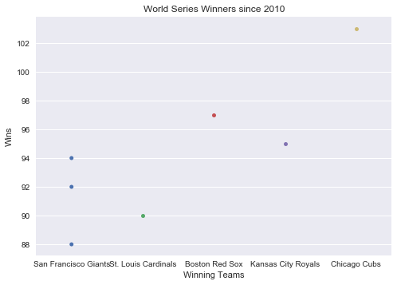

```python
sns.swarmplot(x='name', y='W', data=df_champs.loc[2010:])
plt.title('World Series Winners since 2010')
plt.ylabel('Wins')
plt.xlabel('Winning Teams')
plt.show()
```

The set plot below show champs win and loss columns.

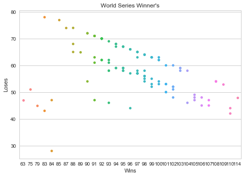

```python
sns.set(style='whitegrid', color_codes=True)
sns.stripplot(x='W', y='L', data=df_champs)
plt.title('World Series Winner\'s')
plt.ylabel('Loses')
plt.xlabel('Wins')
plt.show()
```

One of my favorite Seaborn plots is the .lmplot which shows the win column, the loss columns, and field percentage in relation to them.

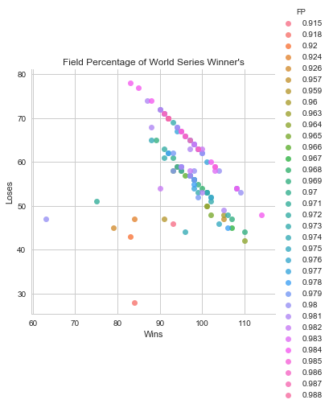

```python
sns.lmplot(x='W', y='L', data=df_champs, fit_reg=False, hue='FP' )
plt.title('Field Percentage of World Series Winner\'s')
plt.ylabel('Loses')
plt.xlabel('Wins')
plt.show()
```

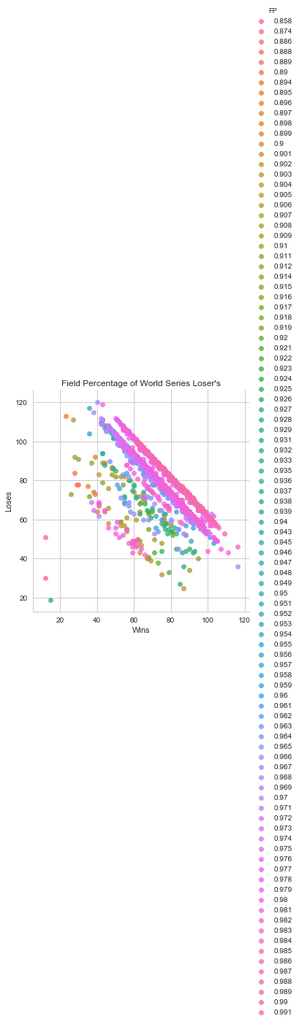

```python
sns.lmplot(x='W', y='L', data=df_losers, fit_reg=False, hue='FP' )
plt.title('Field Percentage of World Series Loser\'s')
plt.ylabel('Loses')
plt.xlabel('Wins')
plt.show()
```

### Summary of Conclusion

##### Missing Values

The code output exectued in the 'Baseball Wrangling' section shows a number of columns with cell values=NaN. I can edit each column individually with a simple code such as, df['col'].fillna(value=n). The variable n can be an arbitrary input of a string or integer. This option is not so desired in the circle of data scientist because its an arbitrary input and can cause misinterpretation of data.

Instead, I can input code such as, df.fillna(df.mode().loc['col'], which will replace all NaN with the mode() function. This function will replace all NaN with the most frequent value within the dataset. This may be slightly more desirable than .fillna(value=0) but there are two other techniques worth noting that are more desirable, (i) regression substitution and (ii) multiple imputation. The later two techniques require machine learning and is beyond the scope of our dataset.

Therefore the solution I propose would be to execute the following code, df1 = df1.fillna(value=0). The code above df1.isnull().sum() shows me columns that do have NaN and by replacing with 0 it's not going to affect our stats. The reason for this is especially when we consider only using 12 out of the 47 columns and are not affected with NaN other than the WSWin column.

##### Missing Observations and Features

While the dataset has tons of information to extract some observations could have made our findings more profound. For example playing sports and executing a game plan require tons of preparation, physically, mentally, and emotionally. Are there settle differences between how teams that win prepare for games in comparison to teams that come short of winning? Are there certain techniques, or training methods that is superior over others? Do winning teams have a certain style of play, for example are they power hitters or more concerned about the quality of their pitching staff? Perhaps team salary has something to do with winning, maybe teams with higher paid players tend to win more often than teams that spend less on players? Some of these observation could play a role in better understanding why only 32 unique teams have ever won the title in over 135 seasons within the dataset.

##### Statistical Tests

We have extracted a the mean, median, and standard deviation however this is just scratching the surface in statistical analysis. More complex algorithms can be coded to better understand statistical relationships.

```
By: Tarique Hasheem
```